# EjRa-23 Lithic Analysis

Nick Waber

2023-04-17

## 3 Results

### 3.1 Temporal and Spatial Distribution

EjRa-23 yielded 172 lithic artifacts and debitage from three excavation units. All of the excavation units are situated in the same site sub-area (the eastern EjRa-23 polygon), but differences in distribution across stratigraphic layers indicate at least two occupations with different spatial characteristics. First, a spatially constrained earlier depositional period is evident in EU 20-02, with high artifact concentrations in Layer C, likely intruding into Layer D (Table 1). No lithics were recovered from Layers C or D in either EU 20-01 or EU 20-03, that are nearly adjacent to each other in the western side of the sub-area. A later depositional horizon is evident in Layers A and B, with lithics from those layers recovered from all of the excavation units, indicating a broader or more transitory occupation. This distinction in temporal/spatial distribution is supported by a Chi-Square test of independence (with simulated P-value based on 2000 replicates to compensate for lower-than-expected frequencies in the contingency table) which showed a significant association between stratigraphic layer and excavatoin unit in artifact frequency (*X^2* = 87.0443278, *p* = 0.0005). A Cramer’s V post-hoc test of strength of association indicates that the association is strong (V = 0.5030267). Because of the difference in deposition, the earlier (Layers C and D) and later (Layers A and B) deposits will be analyzed seperately; the later occupation will be analyzed as a single spatial unit.

| Table 1: Lithic distribution within layers and excavation units | Table 1: Lithic distribution within layers and excavation units Unit No. 20-01 | Table 1: Lithic distribution within layers and excavation units Unit No. 20-02 | Table 1: Lithic distribution within layers and excavation units Unit No. 20-03 |
| --- | --- | --- | --- |
| Layer |  |  |  |
| A | 8 | 0 | 4 |
| A/B | 21 | 18 | 0 |
| B | 8 | 43 | 11 |
| C | 0 | 55 | 0 |
| D | 0 | 4 | 0 |

Most of the assemblage is composed of debitage (*n* = 168; Tables 2-5), with three formal tools and a single expedient tool. There is no significant association between artifact type and stratigraphic layer (*X^2* = 2.2271, *p* = 1).

| Table 2: EjRa-23 lithic artifact type frequencies across strata | Table 2: EjRa-23 lithic artifact type frequencies across strata Type debitage | Table 2: EjRa-23 lithic artifact type frequencies across strata Type expedient tool | Table 2: EjRa-23 lithic artifact type frequencies across strata Type formal tool | Table 2: EjRa-23 lithic artifact type frequencies across strata | Table 2: EjRa-23 lithic artifact type frequencies across strata Sum |
| --- | --- | --- | --- | --- | --- |
| Layer |  |  |  |  |  |
| A | 12 | 0 | 0 |  | 12 |
| A/B | 38 | 0 | 1 |  | 39 |
| B | 60 | 1 | 1 |  | 62 |
| C | 54 | 0 | 1 |  | 55 |
| D | 4 | 0 | 0 |  | 4 |
| Sum | 168 | 1 | 3 |  | 172 |

| Table 3: EjRa-23 lithic artifact type proportions by count across strata | Table 3: EjRa-23 lithic artifact type proportions by count across strata Type debitage | Table 3: EjRa-23 lithic artifact type proportions by count across strata Type expedient tool | Table 3: EjRa-23 lithic artifact type proportions by count across strata Type formal tool | Table 3: EjRa-23 lithic artifact type proportions by count across strata | Table 3: EjRa-23 lithic artifact type proportions by count across strata Sum |
| --- | --- | --- | --- | --- | --- |
| Layer |  |  |  |  |  |
| A | 6.98 | 0 | 0 |  | 6.98 |
| A/B | 22.09 | 0 | 0.58 |  | 22.67 |
| B | 34.88 | 0.58 | 0.58 |  | 36.04 |
| C | 31.4 | 0 | 0.58 |  | 31.98 |
| D | 2.33 | 0 | 0 |  | 2.33 |
| Sum | 97.68 | 0.58 | 1.74 |  | 100 |

| Table 4: EjRa-23 lithic artifact type mass (g) across strata | Table 4: EjRa-23 lithic artifact type mass (g) across strata Type debitage | Table 4: EjRa-23 lithic artifact type mass (g) across strata Type expedient tool | Table 4: EjRa-23 lithic artifact type mass (g) across strata Type formal tool | Table 4: EjRa-23 lithic artifact type mass (g) across strata | Table 4: EjRa-23 lithic artifact type mass (g) across strata Sum |
| --- | --- | --- | --- | --- | --- |
| Layer |  |  |  |  |  |
| A | 1.33 | 0 | 0 |  | 1.33 |
| A/B | 2.6 | 0 | 0.23 |  | 2.83 |
| B | 5.22 | 2.24 | 0.18 |  | 7.64 |
| C | 4.14 | 0 | 1.3 |  | 5.44 |
| D | 0.57 | 0 | 0 |  | 0.57 |
| Sum | 13.86 | 2.24 | 1.71 |  | 17.81 |

| Table 5: EjRa-23 lithic artifact type proportions by mass across strata | Table 5: EjRa-23 lithic artifact type proportions by mass across strata Type debitage | Table 5: EjRa-23 lithic artifact type proportions by mass across strata Type expedient tool | Table 5: EjRa-23 lithic artifact type proportions by mass across strata Type formal tool | Table 5: EjRa-23 lithic artifact type proportions by mass across strata | Table 5: EjRa-23 lithic artifact type proportions by mass across strata Sum |
| --- | --- | --- | --- | --- | --- |
| Layer |  |  |  |  |  |
| A | 7.47 | 0 | 0 |  | 7.47 |
| A/B | 14.6 | 0 | 1.29 |  | 15.89 |
| B | 29.31 | 12.58 | 1.01 |  | 42.9 |
| C | 23.25 | 0 | 7.3 |  | 30.55 |
| D | 3.2 | 0 | 0 |  | 3.2 |
| Sum | 77.83 | 12.58 | 9.6 |  | 100.01 |

### 3.2 Early Occupation

#### 3.2.1 Raw Materials

The earlier occupation from EjRa-23 yielded 59 lithics from Layers C (n = 55) and D (n = 4) in EU 20-02. All of the finds are made from dark grey or black fine-grained volcanic rock (FGV). The material is visually consistent with other FGV from well-documented source localities at Arrowstone Hills, Maiden Creek, and Medicine Creek (Upper Hat Creek Valley) (Rousseau 2015, 2000). Without geochemical analysis we cannot reliably eliminate any of these possible sources, but we propose Arrowstone Hills as the most likely source based on geographic proximity, the association of known Arrowstone quarry locations on travel corridors to/from the North Thompson River, either via the major river valleys or overland through the Bonaparte River/Lake or Green Lake corridors. It is also worth noting that the Clearwater region is a rich volcanic landscape and we must not ignore the possibility of a more local source for FGV.

#### 3.2.4 Debitage

The early component yielded 58 pieces of debitage. The debitage is uniformly small, with most pieces weighing less than 0.1g, and measuring less than 15mm (**Table 6; Figure 2**). This, combined with the absence of any cortical flakes and the high proportion of biface reduction flakes (**Table 7**) is strong evidence for the assemblage reflecting only late-stage lithic reduction activities: finishing and/or re-furbishing tools; likely bifaces (Magne 1989). Further support for this hypothesis comes from a comparison of flake size between biface-reduction flakes (BRF) and other platform remnant-bearing flakes (PRB) with no direct evidence of biface reduction. Because the weight values of the two categories were not normally distributed (Shapiro-Wilk normality test: *W* = 0.72521, *p* = 0.0003244) we used non-parametric Mann-Whitney U tests to examine the relationships between flake mass and flake category. Based on the result of a Wilcoxon Rank-sum test between platform-remnant bearing flakes with and without evidence of bifacial reduction flaking (*W* = 211.5, *p* = 0.4376862), we cannot reject the null hypothesis that there is no statistically significant difference in mass between BRF and non-BRF platform remnant-bearing flakes. To examine size category distribution between the two flake categories we used Fisher’s Exact test of association, which returned no significant result (*p* = 0.3516). On this basis we may infer that BRFs and non-BRF PRBs share similar distributions among the observed size categories (flakes smaller than 10 mm; flakes between 10 and 15 mm; flakes between 15 and 20 mm). The absence of larger flakes in one or the other category suggests that the entire debitage assemblage is the product of similar reduction methods. Thus, the non-BRF flakes are likely from the same flaking activities, and the absence of evidence for bifacial flaking on these pieces is possibly more the result of platform morphology (i.e. complex flake scar patterns are less likely to be present on a very small platform because the platform area covers less space and thus captures fewer flake scars) than difference in knapping strategy.

The corresponding lines of evidence–absence of cortical flakes; abundance of BRFs; very small flakes across all categories— agree well with the formal biface fragment (EjRa-23:185), which shows signs of having been re-sharpened, and broken during a resharpening event. It is worth noting that there are at least two visually distinct FGV materials represented in the debitage, with being a very dark grey-to-black, but some of a particularly smooth texture and deep black hue. Both visual categories are typical of Arrowstone Hills and the other Kamloops Group volcanic lithic material sources, but the presence of at least two visually distinct materials allows us to infer at least two nodules, preforms, or tools being reduced at this place, rather than potentially linking all of the early occupation debitage to EjRa-23:185 (Scerri et al. 2015; Prasciunas 2007; Knell 2012).

| Table 6: EjRa-23 debitage mean weight and size classes n | Table 6: EjRa-23 debitage mean weight and size classes | Table 6: EjRa-23 debitage mean weight and size classes Weight (g) Mean | Table 6: EjRa-23 debitage mean weight and size classes Weight (g) Median | Table 6: EjRa-23 debitage mean weight and size classes | Table 6: EjRa-23 debitage mean weight and size classes Size class (mm) Mean | Table 6: EjRa-23 debitage mean weight and size classes Size class (mm) Median |
| --- | --- | --- | --- | --- | --- | --- |
| 57 |  | 0.08 | 0.06 |  | 11.75 | 10 |

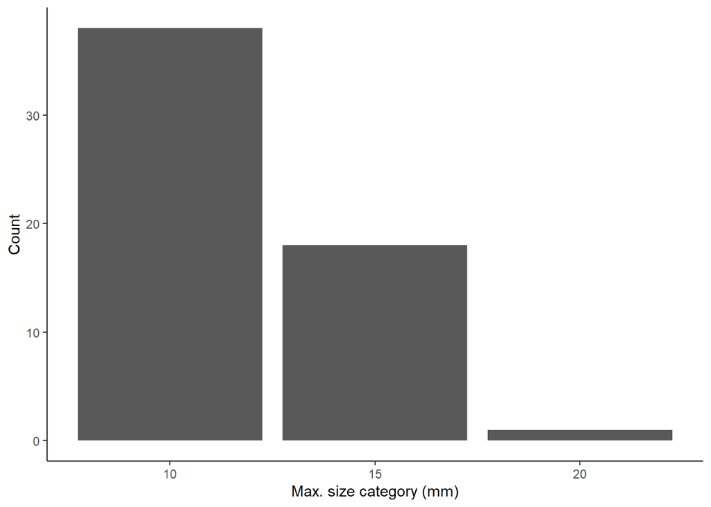

| Table 7: EjRa-23 debitage Count | Table 7: EjRa-23 debitage Cortex | Table 7: EjRa-23 debitage CTX % | Table 7: EjRa-23 debitage BRF | Table 7: EjRa-23 debitage BRF % |
| --- | --- | --- | --- | --- |
| 58 | 0 | 0 | 16 | 27.59 |

| Table 8: EjRa-23 debitage mean weight and size class comparison: BRF vs non-BRF platform remnant bearing flakes Class | Table 8: EjRa-23 debitage mean weight and size class comparison: BRF vs non-BRF platform remnant bearing flakes n | Table 8: EjRa-23 debitage mean weight and size class comparison: BRF vs non-BRF platform remnant bearing flakes | Table 8: EjRa-23 debitage mean weight and size class comparison: BRF vs non-BRF platform remnant bearing flakes Weight (g) Mean | Table 8: EjRa-23 debitage mean weight and size class comparison: BRF vs non-BRF platform remnant bearing flakes Weight (g) Median | Table 8: EjRa-23 debitage mean weight and size class comparison: BRF vs non-BRF platform remnant bearing flakes | Table 8: EjRa-23 debitage mean weight and size class comparison: BRF vs non-BRF platform remnant bearing flakes Size class (mm) Mean | Table 8: EjRa-23 debitage mean weight and size class comparison: BRF vs non-BRF platform remnant bearing flakes Size class (mm) Median |
| --- | --- | --- | --- | --- | --- | --- | --- |
| PRB | 41 |  | 0.07 | 0.04 |  | 11.09 | 10 |
| BRF | 16 |  | 0.08 | 0.06 |  | 12.19 | 10 |

### 3.3 Late Occupation

#### 3.3.1 Raw Materials

#### 3.3.2 Expedient Tools

#### 3.3.3 Formal Tools

#### 3.3.4 Debitage

#### 3.3.5 Summary

## 4 Conclusions

### References

Knell, Edward J. 2012. “Minimum Analytical Nodules and Late Paleoindian Cody Complex Lithic Technological Organization at Hell Gap, Wyoming.” *Plains Anthropologist* 57 (224): 325–51. https://doi.org/10.1179/pan.2012.024.

Magne, Martin P. R. 1989. “Lithic Reduction Stages and Assemblage Formation Processes.” In, edited by Daniel S. Amick and Raymond P. Mauldin, 15–31. Oxford: B.A.R. International Series. papers://615a4f4f-b055-4473-890f-e54cd7661df9/Paper/p175.

Pokotylo, David L., and Donald H. Mitchell. 1998. “Prehistory of the Northern Plateau.” In, edited by Deward E. Walker, 11:81–102. Washington, DC: Smithsonian Institution.

Prasciunas, Mary M. 2007. “Bifacial Cores and Flake Production Efficiency: An Experimental Test of Technological Assumptions.” *American Antiquity* 72 (2): 334–48. http://www.jstor.org/stable/10.2307/40035817.

Richards, Thomas H., and Michael K. Rousseau. 1987. *Late Prehistoric Cultural Horizons on the Canadian Plateau*. Publication / Dept. Of Archaeology, Simon Fraser University, no. 16. Burnaby, B.C: Dept. of Archaeology, Simon Fraser University.

Rousseau, Mike K. 2000. “Results of the Keatley Creek Archaeological Project Lithic Source Study.” In, edited by Brian Hayden, 165–84. Burnaby, BC: SFU Archaeology Press.

———. 2008. “Chipped Stone Bifaces as Cultural, Behavioural, and Temporal Indices on the Central Canadian Plateau.” In, edited by Roy L. Carlson and Martin P. R. Magne, 221–50. Burnaby, BC: SFU Archaeology Press.

———. 2015. “Primary Toolstone Sources and Pre-Contact Period Quarrying Behaviour in the Thompson River Drainage of South Central British Columbia.” In, edited by Terry L. Ozbun and Ron L. Adams, 29–48. Burnaby, BC: SFU Archaeology Press.

Scerri, Eleanor M. L., Brad Gravina, James Blinkhorn, and Anne Delagnes. 2015. “Can Lithic Attribute Analyses Identify Discrete Reduction Trajectories? A Quantitative Study Using Refitted Lithic Sets.” *Journal of Archaeological Method and Theory*. https://doi.org/10.1007/s10816-015-9255-x.